# Workshop 3: Writing Up Reports with RMarkdown

# References

For references, RMarkdown is able to make use of the very powerful BibTex format. This is a rather simple, three-step procedure that will store your bibliographic metadata, automatically include references where you want them, create a References block at the end of your document.

First, open a new document and save it as `bibfile.bib`.

Then, include the following line in your header `bibliography: bibfile.bib`.

```
---
title: "Report"
subtitle: "Your Class"
author: "Your Name"
date: 'September 2018'
output: pdf_document
bibliography: bibfile.bib
---
```

Then, go on Google Scholar and search for an article you want to include as a reference. This is for demonstrational reasons, of course you can use any search engine or none at all in your research. lick on the quotation marks `"` below the search results, then click ‘BibTex’ and copy the resulting text in your own *.bib* file.

[figure not shown]

Finding BibTex fomrat metadata

```r
knitr::include_graphics('scholar1.png')
```

[figure not shown]

Finding BibTex fomrat metadata

```r
knitr::include_graphics('scholar2.png')
```

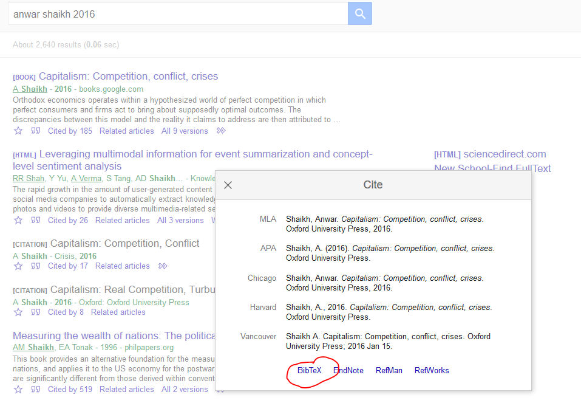

Finding BibTex fomrat metadata

```r
knitr::include_graphics('scholar3.png')
```

The *pandoc* style for PDF documents RStudio uses by default will just give you all citations that you used as a Reference block at the end of your document. If you want this to have a title (which you normally do), just close your document with `#References`. You can also use `nocite` in your metadata header to inculde uncited documents.

# Table of Contents

Tables of Content are especially nice as navigations in HTML documents. However, even when compiling to a PDF a TOC works as structuring your document and giving an overview at the beginning. Just include the following two lines in your metadata header: `toc: yes` and `toc_depth: '2'`. It should then look like the following:

```
---
title: "Report"
subtitle: "Your Class"
author: "Your Name"
date: 'September 2018'
output:
  pdf_document:
      toc: yes
      toc_depth: '2'
bibliography: bibfile.bib
---
```

# Extract pure R code

To extract all R code from an RMarkdown file you can use the package *knitr*’s `purl()` function. Make sure you have *knitr* installed and activated, and your working directory set, so that you can easily find the R output.

```r
install.packages('knitr')
library('knitr')
setwd('C/User/Documents/R/RMD')
purl('filename.rmd')
```

# Troubleshooting

For some reason, the newest installation of RMarkdown is not working for all users when knitting to PDF. If you run into this problem, try (one by one) the following code lines.

First try updating all your packages. Naturally, check if *rmarkdown*, *stringi* and *tinytex* are installed and work well.

```r
update.packages(ask=FALSE)
```

The following is a temporary, bad fix, however, some users on the web report it is the only solution they have found so far. It includes downgrading to RMarkdown 1.8 and using MikTex, not tinytex, as a PDF compiler. In general, ‘downdating’ your software is a bad idea.

```r
install.packages('devtools')
devtools::install_version('rmarkdown', version = '1.8')
```

You also might have to update your MikTex installation and manually install/update the *fancyvrb* package.

# Further Reading and Practice

https://rmarkdown.rstudio.com/lesson-1.html https://bookdown.org/yihui/rmarkdown/

# References